| **Computer Networks - 2021/22** |  | **Assignment:** | Lab 0 |
| --- | --- | --- | --- |
| Setup the lab environment Virtual Machine |  | **Issued:** | 2021-11-29 |
| Laboratory Environment Setup |  | **Due:** |  |
| **Authors:** | João Romeiras Amado Prof. Luis D. Pedrosa | **Version:** | 0.1 |

# 1 Virtual Machine Setup

The laboratory exercises will be executed on a virtual machine environment. A complete vm image (.ova) is provided in the link below, containing the necessary software and configuration files for all laboratory exercises.

[RC.ova](https://drive.google.com/file/d/1CItnukXtbMyLYml-tSOymgS9NKXc_gxE/view?usp=sharing)

The recommended software to run the .ova image is VirtualBox, which is available for Windows, MacOS and Linux. It can be downloaded from: https://www.virtualbox.org/wiki/Downloads. After the installation, you can directly import the .ova image from the VirtualBox import dialog.

[figure not shown]

VirtualBox Import Dialog

**Important.** The folder `/home/rc/lab-files` in the VM contains important configuration files for each lab. Before starting each lab, execute the command `git pull origin master` inside that folder in order to make sure you have the latest files relevant for the lab. Each lab handout will remember you to execute this command in the beggining. *It is very important that you do not skip this step.*

# 2 CORE Network Emulator Test

The CORE Network Emulator is a tool to build and simulate network topologies in a virtualized environment. During the course, many laboratory exercises will be executed within CORE. The provided .ova already contains a configured CORE emulator, along with a number of topology configuration files.

Network topologies can easily be configured and executed using CORE’s GUI, which can be accessed from the program menu.

To observe and test a simple topology on the CORE emulator, open the `setup-0.imn` configuration file (`File` > `Open...` > `/home/rc/lab-files/lab-setup/setup-0.imn`). The topology should appear as in the image below.

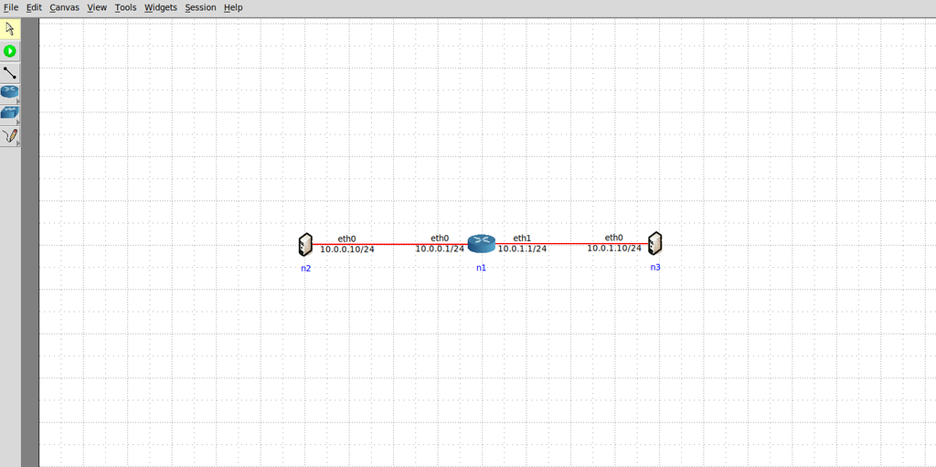

CORE GUI - Simple Topology

To activate the topology, select the ‘start the session’ button from the side bar. The various nodes in the topology should become green for a few seconds, indicating their active status in the emulated network. To deactivate the topology, simply press the session button again.

Whenever is requested that you run commands on a given host, first start a session and then double-click on the host to open the terminal related to that specific host. For example, to run the command `hostname` on host `n2`, double-click on `n2` and run `hostname`:

[figure not shown]

CORE GUI - hostname on n2